# MIMIC-III Admissions Table

efg | 2018-12-30

NOTES:

- RPostgreSQL works fine with dates before 1970, but seems to truncate datetime timestamps to dates, and does not compute time intervals correctly.
- Rpostgres does NOT work with dates before 1970 (*fix expected in Feb. 2019*), but computes time intervals below correctly.

Online [info about the admissions table](https://mimic.physionet.org/mimictables/admissions/). See info about `admissions` table in [online schema](https://mit-lcp.github.io/mimic-schema-spy/tables/admissions.html).

# 1 Setup

## 1.1 Packages

```r
library(DBI)
library(RPostgres)   # be cautious with dates before 1970 with RPostgres
library(tidyverse)
```

```r
library(dbplyr, warn.conflicts=FALSE)
library(kableExtra)
library(ggplot2)
library(writexl)
```

## 1.2 Helper function

```r
Show <- function(data)
{
  data            %>%
  kable("html")   %>%
  kable_styling(bootstrap_options = c("striped", "bordered", "condensed"),
                position = "left", full_width = FALSE)
}
```

## 1.3 Open database

```r
MimicDB <- dbConnect(RPostgres::Postgres(),
                     dbname   = "mimic",
                     user     = Sys.getenv("MIMIC_User"),
                     password = Sys.getenv("MIMIC_Password"),
                     options  = "-c search_path=mimiciii")

plotCaptionLeft  <- "MIMIC-III v1.4"
plotCaptionRight <- paste("efg", format(Sys.time(), "%Y-%m-%d"))
```

# 2 List tables in database

This works with RPostgres but not RPostgreSQL.

```r
dbListTables(MimicDB)
```

```
 [1] "admissions"         "callout"            "caregivers"
 [4] "chartevents_1"      "chartevents_2"      "chartevents_3"
 [7] "chartevents_4"      "chartevents_5"      "chartevents_6"
[10] "chartevents_7"      "chartevents_8"      "chartevents_9"
[13] "chartevents_10"     "chartevents_11"     "chartevents_12"
[16] "chartevents_13"     "chartevents_14"     "chartevents_15"
[19] "chartevents_16"     "chartevents_17"     "chartevents"
[22] "cptevents"          "datetimeevents"     "diagnoses_icd"
[25] "drgcodes"           "d_cpt"              "d_icd_diagnoses"
[28] "d_icd_procedures"   "d_items"            "d_labitems"
[31] "icustays"           "inputevents_cv"     "inputevents_mv"
[34] "labevents"          "microbiologyevents" "noteevents"
[37] "outputevents"       "patients"           "prescriptions"
[40] "procedureevents_mv" "procedures_icd"     "services"
[43] "transfers"
```

# 3 List of fields in admissions table

```r
dbListFields(MimicDB, "admissions")
```

```
 [1] "row_id"               "subject_id"           "hadm_id"
 [4] "admittime"            "dischtime"            "deathtime"
 [7] "admission_type"       "admission_location"   "discharge_location"
[10] "insurance"            "language"             "religion"
[13] "marital_status"       "ethnicity"            "edregtime"
[16] "edouttime"            "diagnosis"            "hospital_expire_flag"
[19] "has_chartevents_data"
```

# 4 Admissions table record count

tbl - create a table from a data source

in_schema - refer to a table in a schema. Here schema is “mimiciii” and table is “admissions”.

```r
admissions <- tbl(MimicDB, in_schema("mimiciii", "admissions"))
```

```r
admissions           %>%
  summarize(n = n()) %>%
  Show()
```

| n |
| --- |
| 58976 |

# 5 Sample admissions records

```r
admissions   %>%
  head(5)    %>%
  Show()
```

| row_id | subject_id | hadm_id | admittime | dischtime | deathtime | admission_type | admission_location | discharge_location | insurance | language | religion | marital_status | ethnicity | edregtime | edouttime | diagnosis | hospital_expire_flag | has_chartevents_data |
| --- | --- | --- | --- | --- | --- | --- | --- | --- | --- | --- | --- | --- | --- | --- | --- | --- | --- | --- |
| 21 | 22 | 165315 | 2196-04-09 12:26:00 | 2196-04-10 15:54:00 | NA | EMERGENCY | EMERGENCY ROOM ADMIT | DISC-TRAN CANCER/CHLDRN H | Private | NA | UNOBTAINABLE | MARRIED | WHITE | 2196-04-09 10:06:00 | 2196-04-09 13:24:00 | BENZODIAZEPINE OVERDOSE | 0 | 1 |
| 22 | 23 | 152223 | 2153-09-03 07:15:00 | 2153-09-08 19:10:00 | NA | ELECTIVE | PHYS REFERRAL/NORMAL DELI | HOME HEALTH CARE | Medicare | NA | CATHOLIC | MARRIED | WHITE | NA | NA | CORONARY ARTERY DISEASEARTERY BYPASS GRAFT/SDA | 0 | 1 |
| 23 | 23 | 124321 | 2157-10-18 19:34:00 | 2157-10-25 14:00:00 | NA | EMERGENCY | TRANSFER FROM HOSP/EXTRAM | HOME HEALTH CARE | Medicare | ENGL | CATHOLIC | MARRIED | WHITE | NA | NA | BRAIN MASS | 0 | 1 |
| 24 | 24 | 161859 | 2139-06-06 16:14:00 | 2139-06-09 12:48:00 | NA | EMERGENCY | TRANSFER FROM HOSP/EXTRAM | HOME | Private | NA | PROTESTANT QUAKER | SINGLE | WHITE | NA | NA | INTERIOR MYOCARDIAL INFARCTION | 0 | 1 |
| 25 | 25 | 129635 | 2160-11-02 02:06:00 | 2160-11-05 14:55:00 | NA | EMERGENCY | EMERGENCY ROOM ADMIT | HOME | Private | NA | UNOBTAINABLE | MARRIED | WHITE | 2160-11-02 01:01:00 | 2160-11-02 04:27:00 | ACUTE CORONARY SYNDROME | 0 | 1 |

# 6 Fields

## 6.1 row_id

```r
admissions                                            %>%
  summarize(n = n(),
            distinctRowID = n_distinct(row_id),
            minRowID      = min(row_id, na.rm=TRUE),
            maxRowID      = max(row_id, na.rm=TRUE))  %>%
  collect()                                           %>%
  Show()
```

| n | distinctRowID | minRowID | maxRowID |
| --- | --- | --- | --- |
| 58976 | 58976 | 1 | 58976 |

## 6.2 subject_id

Foreign key. Identifies the patient.

Parent is patients table.

```r
admissions                                                   %>%
  summarize(n = n(),
            distinctSubjectID = n_distinct(subject_id),
            minSubjectID      = min(subject_id, na.rm=TRUE),
            maxSubjectID      = max(subject_id, na.rm=TRUE)) %>%
  Show()
```

| n | distinctSubjectID | minSubjectID | maxSubjectID |
| --- | --- | --- | --- |
| 58976 | 46520 | 2 | 99999 |

There are two groups of `subject _id` ranges.

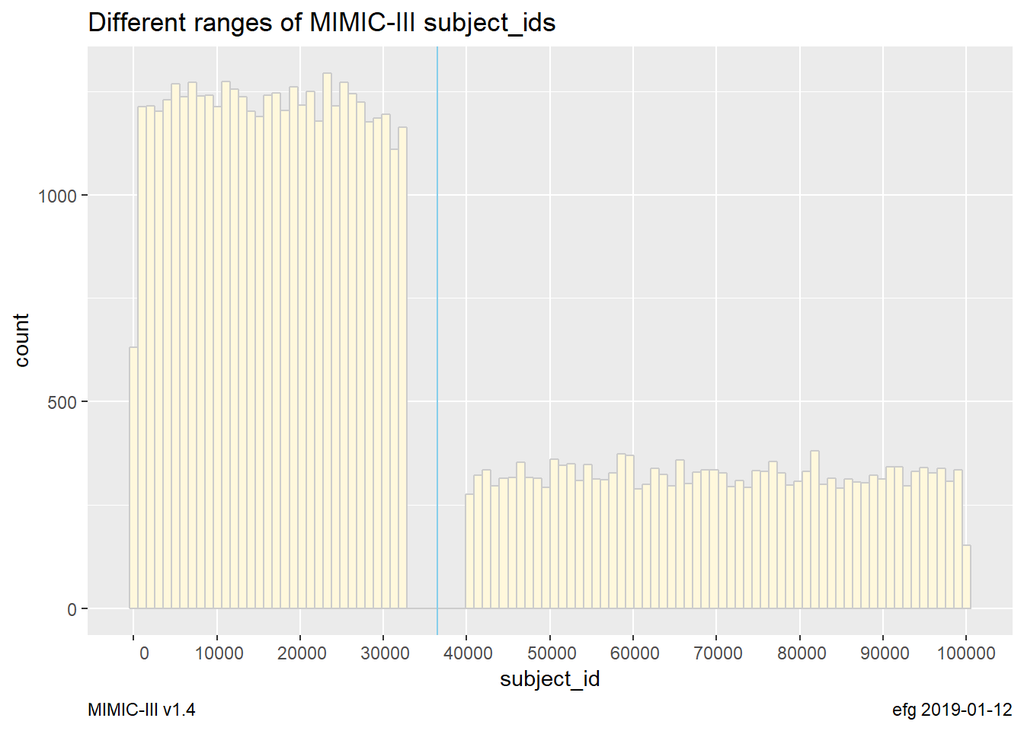

```r
admissions              %>%
  select(subject_id)    %>%
  collect               %>%
  ggplot(aes(x=subject_id))                                 +
  geom_histogram(fill="cornsilk", color="grey80", bins=100) +
  scale_x_continuous(breaks = 0:10 * 10000,
                     labels = function(n){format(n, scientific = FALSE)},
                     minor_breaks = NULL)                   +
  geom_vline(xintercept = 36500, color = "skyblue")         +
  labs(title = "Different ranges of MIMIC-III subject_ids",
       caption=c(plotCaptionLeft, plotCaptionRight))        +
  theme(plot.caption = element_text(hjust=c(0.0,1.0)))
```

The reason for a break in the subject_ids from ~33000 to 40000 is unclear.

Also unclear is why the counts are higher for the lower subject_ids and lower for the higher subject_ids.

## 6.3 hadm_id

Primary key: Identifies the hospital stay

```r
admissions                                         %>%
  summarize(n = n(),
            distinctHadm = n_distinct(hadm_id),
            minHadmID = min(hadm_id, na.rm=TRUE),
            maxHadmID = max(hadm_id, na.rm=TRUE))  %>%
  collect()                                        %>%
  Show()
```

| n | distinctHadm | minHadmID | maxHadmID |
| --- | --- | --- | --- |
| 58976 | 58976 | 100001 | 199999 |

## 6.4 admittime, dischtime, deathtime

- Time of admission to the hospital.
- Time of discharge from the hospital.
- Time of death (only if death occurred in hospital). SHould match time of discharge when present.

sample values

Unclear why time differences are in minutes here.

```r
admissions                                                   %>%
  select(admittime, dischtime, deathtime)                    %>%
  collect()                                                  %>%
  mutate(StayDays = as.double(dischtime - admittime) /1440)  %>%
  head(10)  %>%
  Show()
```

| admittime | dischtime | deathtime | StayDays |
| --- | --- | --- | --- |
| 2196-04-09 12:26:00 | 2196-04-10 15:54:00 | NA | 1.144444 |
| 2153-09-03 07:15:00 | 2153-09-08 19:10:00 | NA | 5.496528 |
| 2157-10-18 19:34:00 | 2157-10-25 14:00:00 | NA | 6.768056 |
| 2139-06-06 16:14:00 | 2139-06-09 12:48:00 | NA | 2.856944 |
| 2160-11-02 02:06:00 | 2160-11-05 14:55:00 | NA | 3.534028 |
| 2126-05-06 15:16:00 | 2126-05-13 15:00:00 | NA | 6.988889 |
| 2191-11-30 22:16:00 | 2191-12-03 14:45:00 | NA | 2.686806 |
| 2177-09-01 07:15:00 | 2177-09-06 16:00:00 | NA | 5.364583 |
| 2172-10-14 14:17:00 | 2172-10-19 14:37:00 | NA | 5.013889 |
| 2108-08-22 23:27:00 | 2108-08-30 15:00:00 | 2108-08-30 15:00:00 | 7.647917 |

How does visit time vary?

Length of Stay = Discharge Time - Admit Time

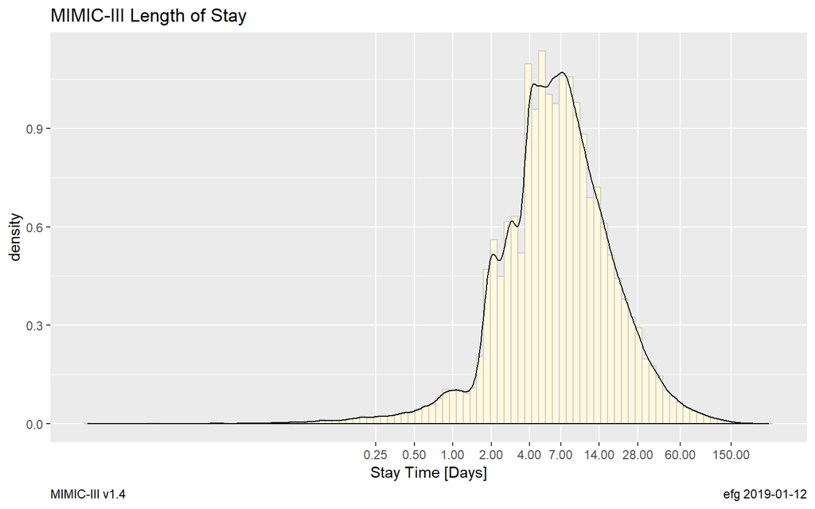

```r
admissions %>%
  select(admittime, dischtime, deathtime)                     %>%
  collect()                                                   %>%
  mutate(StayDays = as.double(dischtime - admittime) / 1440)  %>%
  filter(StayDays > 0)                                        %>%

  ggplot(aes(x = StayDays, y = ..density..))                       +
    geom_histogram(fill="cornsilk", color="grey80", bins = 100)    +
    geom_density()                                                 +
    scale_x_log10(breaks = c(0.25, 0.50, 1, 2, 4, 7, 14, 28, 60, 150),
                  minor_breaks = NULL)                             +
    labs(title="MIMIC-III Length of Stay",
         x = "Stay Time [Days]",
         caption=c(plotCaptionLeft, plotCaptionRight))             +
    theme(plot.caption = element_text(hjust=c(0.0,1.0)))
```

deathtime is mostly missing

```r
admissions                  %>%
  filter(is.na(deathtime))  %>%
  count()                   %>%
  collect()                 %>%
  Show()
```

| n |
| --- |
| 53122 |

What are the death years?

```r
deathStats <-
  admissions                                    %>%
  select(deathtime)                             %>%
  filter(!is.na(deathtime))                     %>%
  collect()                                     %>%
  mutate(deathYear = as.numeric(substr(deathtime, 1, 4)))   %>%
  select(deathYear)                             %>%
  group_by(deathYear)                           %>%
  count()
```

```r
c(nrow(deathStats), sum(deathStats$n))
```

```
[1]  109 5854
```

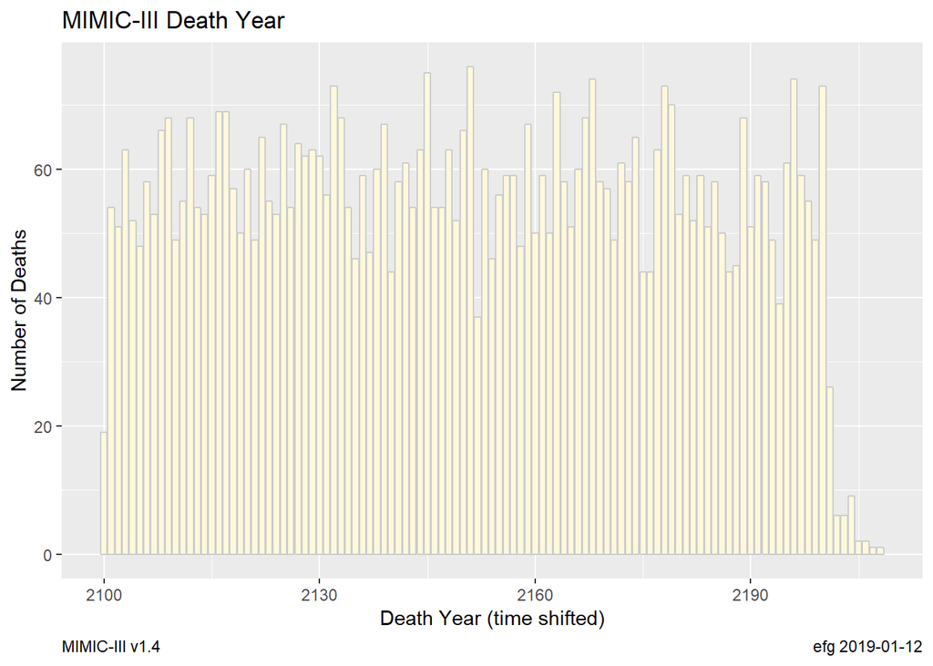

```r
ggplot(data=deathStats, aes(x=deathYear, y=n))                  +
  geom_bar(stat="identity", fill="cornsilk", colour="grey80")   +
  labs(title="MIMIC-III Death Year",
         x = "Death Year (time shifted)",
         y = "Number of Deaths",
         caption=c(plotCaptionLeft, plotCaptionRight))          +
    theme(plot.caption = element_text(hjust=c(0.0,1.0)))
```

```r
c(min(deathStats$deathYear), max(deathStats$deathYear))
```

```
[1] 2100 2208
```

Are deaths spread somewhat uniformly by month? Roughly, yes.

```r
deathInfo <-
  admissions                                    %>%
  select(deathtime)                             %>%
  filter(!is.na(deathtime))                     %>%
  collect()                                     %>%
  mutate(deathYear  = as.numeric(substr(deathtime, 1, 4)),
         deathMonth = as.numeric(substr(deathtime, 6, 7)))
```

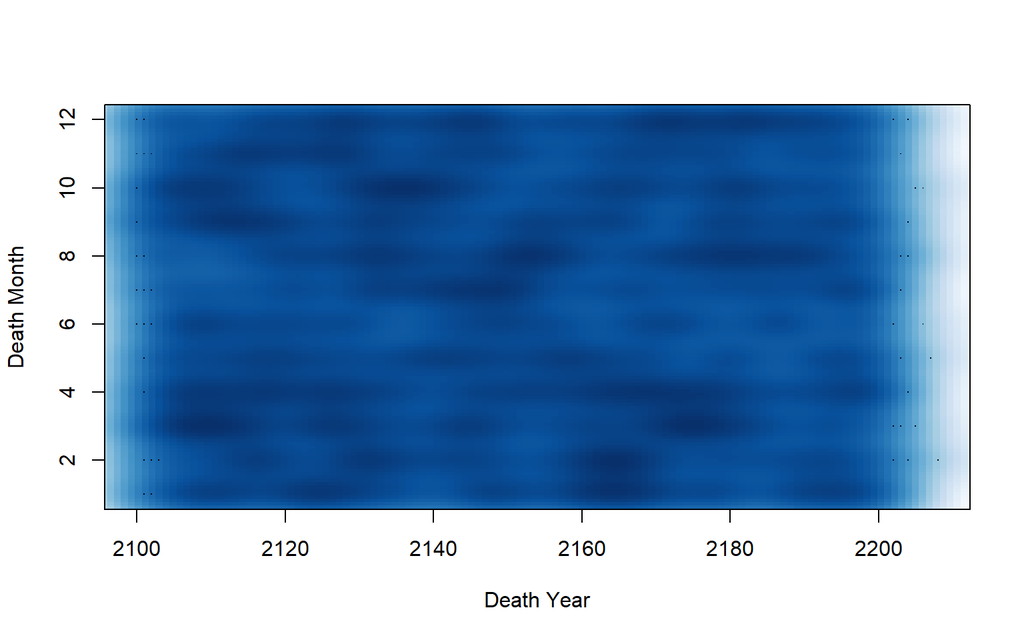

```r
smoothScatter(deathInfo$deathYear,
              deathInfo$deathMonth,
              xlab = "Death Year",
              ylab = "Death Month")
```

The expectation is the above scatterplot should be mostly random.

## 6.5 admission_type

```r
admissions                      %>%
  group_by(admission_type)      %>%
  summarize(n = n())            %>%
  Show()
```

| admission_type | n |
| --- | --- |
| URGENT | 1336 |
| NEWBORN | 7863 |
| ELECTIVE | 7706 |
| EMERGENCY | 42071 |

## 6.6 admission_location

```r
admissions                      %>%
  group_by(admission_location)  %>%
  summarize(n = n())            %>%
  Show()
```

| admission_location | n |
| --- | --- |
| CLINIC REFERRAL/PREMATURE | 12032 |
| ** INFO NOT AVAILABLE ** | 204 |
| TRANSFER FROM HOSP/EXTRAM | 8456 |
| EMERGENCY ROOM ADMIT | 22754 |
| TRANSFER FROM SKILLED NUR | 273 |
| PHYS REFERRAL/NORMAL DELI | 15079 |
| TRANSFER FROM OTHER HEALT | 71 |
| HMO REFERRAL/SICK | 102 |
| TRSF WITHIN THIS FACILITY | 5 |

## 6.7 discharge_location

```r
admissions                      %>%
  group_by(discharge_location)  %>%
  summarize(n = n())            %>%
  Show()
```

| discharge_location | n |
| --- | --- |
| ICF | 47 |
| HOSPICE-MEDICAL FACILITY | 153 |
| DISC-TRAN CANCER/CHLDRN H | 669 |
| DEAD/EXPIRED | 5854 |
| HOME | 18962 |
| LEFT AGAINST MEDICAL ADVI | 365 |
| SNF-MEDICAID ONLY CERTIF | 1 |
| REHAB/DISTINCT PART HOSP | 6429 |
| HOME WITH HOME IV PROVIDR | 67 |
| DISC-TRAN TO FEDERAL HC | 11 |
| LONG TERM CARE HOSPITAL | 2305 |
| SNF | 7705 |
| SHORT TERM HOSPITAL | 1534 |
| OTHER FACILITY | 63 |
| HOSPICE-HOME | 402 |
| HOME HEALTH CARE | 13963 |
| DISCH-TRAN TO PSYCH HOSP | 446 |

## 6.8 insurance

```r
admissions                      %>%
  group_by(insurance)           %>%
  summarize(n = n())            %>%
  Show()
```

| insurance | n |
| --- | --- |
| Government | 1783 |
| Self Pay | 611 |
| Medicare | 28215 |
| Private | 22582 |
| Medicaid | 5785 |

## 6.9 language

```r
admissions                      %>%
  group_by(language)            %>%
  summarize(n = n())            %>%
  Show()                        %>%
  scroll_box(height = "500px")
```

language

n

SOMA

13

SERB

1

**TO

3

*YOR

1

*ARM

9

VIET

94

*IBO

4

*PUN

1

*HUN

7

*PER

1

KORE

23

*KHM

2

JAPA

3

*FAR

1

HAIT

150

NA

25332

*BUR

4

THAI

12

HIND

24

CANT

413

MAND

156

*CAN

2

*GUJ

7

ETHI

11

GREE

75

*MAN

3

ITAL

124

POLI

34

*LIT

1

*CDI

4

*MOR

2

*TOI

2

FREN

16

*DUT

2

*BOS

1

*DEA

1

*FIL

1

*BEN

7

*URD

4

*ROM

1

*LEB

2

CAPE

256

*TOY

2

*PHI

1

*BUL

5

LAOT

7

TAGA

3

- BE

2

*ARA

1

- FU

1

*NEP

1

TURK

2

SPAN

1083

PERS

44

*AMH

2

*CRE

1

CAMB

37

BENG

2

PTUN

628

*TAM

1

ARAB

47

** T

1

PORT

342

*YID

7

*SPA

1

**SH

2

*RUS

1

*CHI

7

*TEL

3

ENGL

29086

AMER

31

ALBA

17

GERM

1

URDU

5

*FUL

2

RUSS

790

## 6.10 religion

```r
admissions                      %>%
  group_by(religion)            %>%
  summarize(n = n())            %>%
  Show()
```

| religion | n |
| --- | --- |
| NA | 458 |
| OTHER | 2696 |
| CATHOLIC | 20606 |
| HINDU | 113 |
| EPISCOPALIAN | 774 |
| METHODIST | 7 |
| HEBREW | 16 |
| UNOBTAINABLE | 8269 |
| 7TH DAY ADVENTIST | 81 |
| PROTESTANT QUAKER | 7134 |
| JEHOVAH’S WITNESS | 139 |
| NOT SPECIFIED | 11753 |
| BAPTIST | 28 |
| ROMANIAN EAST. ORTH | 83 |
| BUDDHIST | 267 |
| UNITARIAN-UNIVERSALIST | 124 |
| GREEK ORTHODOX | 459 |
| LUTHERAN | 1 |
| MUSLIM | 225 |
| JEWISH | 5314 |
| CHRISTIAN SCIENTIST | 429 |

## 6.11 marital_status

```r
admissions                      %>%
  group_by(marital_status)      %>%
  summarize(n = n())            %>%
  Show()
```

| marital_status | n |
| --- | --- |
| DIVORCED | 3213 |
| SEPARATED | 571 |
| LIFE PARTNER | 15 |
| SINGLE | 13254 |
| UNKNOWN (DEFAULT) | 345 |
| NA | 10128 |
| MARRIED | 24239 |
| WIDOWED | 7211 |

## 6.12 ethnicity

```r
admissions                      %>%
  group_by(ethnicity)           %>%
  summarize(n = n())            %>%
  Show()                        %>%
  scroll_box(height = "500px")
```

| ethnicity | n |
| --- | --- |
| BLACK/HAITIAN | 101 |
| PORTUGUESE | 61 |
| SOUTH AMERICAN | 8 |
| HISPANIC/LATINO - SALVADORAN | 19 |
| HISPANIC/LATINO - COLOMBIAN | 9 |
| BLACK/AFRICAN | 44 |
| WHITE - OTHER EUROPEAN | 81 |
| HISPANIC/LATINO - CENTRAL AMERICAN (OTHER) | 13 |
| ASIAN - VIETNAMESE | 53 |
| CARIBBEAN ISLAND | 9 |
| WHITE - EASTERN EUROPEAN | 25 |
| OTHER | 1512 |
| ASIAN | 1509 |
| ASIAN - THAI | 4 |
| ASIAN - ASIAN INDIAN | 85 |
| MIDDLE EASTERN | 43 |
| HISPANIC/LATINO - CUBAN | 24 |
| HISPANIC/LATINO - PUERTO RICAN | 232 |
| UNKNOWN/NOT SPECIFIED | 4523 |
| HISPANIC/LATINO - HONDURAN | 4 |
| ASIAN - KOREAN | 13 |
| ASIAN - CHINESE | 277 |
| BLACK/AFRICAN AMERICAN | 5440 |
| AMERICAN INDIAN/ALASKA NATIVE | 51 |
| NATIVE HAWAIIAN OR OTHER PACIFIC ISLANDER | 18 |
| ASIAN - FILIPINO | 25 |
| BLACK/CAPE VERDEAN | 200 |
| MULTI RACE ETHNICITY | 130 |
| HISPANIC OR LATINO | 1696 |
| HISPANIC/LATINO - GUATEMALAN | 40 |
| WHITE | 40996 |
| WHITE - BRAZILIAN | 59 |
| WHITE - RUSSIAN | 164 |
| AMERICAN INDIAN/ALASKA NATIVE FEDERALLY RECOGNIZED TRIBE | 3 |
| ASIAN - OTHER | 17 |
| ASIAN - CAMBODIAN | 17 |
| PATIENT DECLINED TO ANSWER | 559 |
| UNABLE TO OBTAIN | 814 |
| HISPANIC/LATINO - MEXICAN | 13 |
| ASIAN - JAPANESE | 7 |
| HISPANIC/LATINO - DOMINICAN | 78 |

## 6.13 edregtime, edouttime

- Emergency Department Registation Time
- Emergency Department Discharge Time

```r
admissions                      %>%
  select(edregtime, edouttime)  %>%
  head(5)                       %>%
  collect()                     %>%
  Show()
```

| edregtime | edouttime |
| --- | --- |
| 2196-04-09 10:06:00 | 2196-04-09 13:24:00 |
| NA | NA |
| NA | NA |
| NA | NA |
| 2160-11-02 01:01:00 | 2160-11-02 04:27:00 |

```r
admissions                  %>%
 filter(is.na(edregtime))   %>%
  count()                   %>%
  collect()                 %>%
  Show()
```

| n |
| --- |
| 28099 |

```r
admissions                   %>%
  filter(!is.na(edouttime))  %>%
  count()                    %>%
  collect()                  %>%
  Show()
```

| n |
| --- |
| 30877 |

### 6.13.1 Emergency room length of stay

```r
ERStay <-
  admissions                    %>%
  filter(!is.na(edregtime),
         !is.na(edouttime))     %>%
  select(edregtime, edouttime)  %>%
  collect()                     %>%
  mutate(ERStayMinutes = as.double(edouttime - edregtime) / 60)

nrow(ERStay)
```

```
## [1] 30877
```

```r
ERStay %>% head() %>% Show()
```

| edregtime | edouttime | ERStayMinutes |
| --- | --- | --- |
| 2196-04-09 10:06:00 | 2196-04-09 13:24:00 | 198 |
| 2160-11-02 01:01:00 | 2160-11-02 04:27:00 | 206 |
| 2116-12-23 14:42:00 | 2116-12-23 23:41:00 | 539 |
| 2191-02-23 04:23:00 | 2191-02-23 07:25:00 | 182 |
| 2131-05-12 17:26:00 | 2131-05-12 22:17:00 | 291 |
| 2183-08-21 05:58:00 | 2183-08-21 17:45:00 | 707 |

```r
quantile(ERStay$ERStayMinutes,
         c(0.00, 0.01, 0.25, 0.50, 0.75, 0.99, 1.00))
```

```
##        0%        1%       25%       50%       75%       99%      100%
## -41749.00     41.00    203.00    296.00    420.00   1341.24   4228.00
```

How does ER time vary?

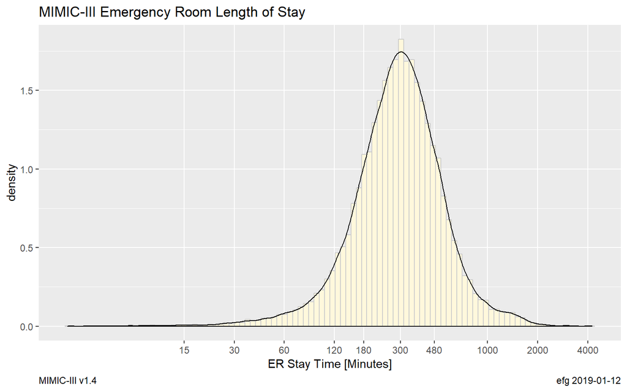

```r
ERStay                        %>%
  filter(ERStayMinutes > 0)   %>%

  ggplot(aes(x = ERStayMinutes, y = ..density..))                  +
    geom_histogram(fill="cornsilk", color="grey80", bins=100)      +
    geom_density()                                                 +
    scale_x_log10(breaks = c(0, 15, 30, 60, 120, 180, 300, 480, 1000, 2000, 4000),
                  minor_breaks = NULL)                             +
    labs(title="MIMIC-III Emergency Room Length of Stay",
         x = "ER Stay Time [Minutes]",
         caption=c(plotCaptionLeft, plotCaptionRight))             +
    theme(plot.caption = element_text(hjust=c(0.0,1.0)))
```

## 6.14 diagnosis

Preliminary, free text diagnosis for the patient on hospital admission. The diagnosis is usually assigned by the admitting clinician and does not use a systematic ontology.

Final diagnoses for hospital admissions are coded and can be found in the DIAGNOSES_ICD table

```r
diagnosisCounts <-
  admissions                 %>%
  group_by(diagnosis)        %>%
  summarize(n = n())         %>%
  collect()

nrow(diagnosisCounts)
```

```
## [1] 15692
```

top 20

```r
diagnosisCounts             %>%
  arrange(desc(n))          %>%
  head(20)                  %>%
  Show()
```

| diagnosis | n |
| --- | --- |
| NEWBORN | 7823 |
| PNEUMONIA | 1566 |
| SEPSIS | 1184 |
| CONGESTIVE HEART FAILURE | 928 |
| CORONARY ARTERY DISEASE | 840 |
| CHEST PAIN | 778 |
| INTRACRANIAL HEMORRHAGE | 713 |
| ALTERED MENTAL STATUS | 712 |
| GASTROINTESTINAL BLEED | 686 |
| CORONARY ARTERY DISEASEARTERY BYPASS GRAFT /SDA | 583 |
| UPPER GI BLEED | 580 |
| ABDOMINAL PAIN | 554 |
| FEVER | 510 |
| DIABETIC KETOACIDOSIS | 462 |
| CORONARY ARTERY DISEASEARTERY BYPASS GRAFT/SDA | 450 |
| S/P FALL | 444 |
| LOWER GI BLEED | 442 |
| SUBARACHNOID HEMORRHAGE | 440 |
| HYPOTENSION | 416 |
| STROKE;TELEMETRY;TRANSIENT ISCHEMIC ATTACK | 341 |

Write to file for further study.

A number of diagnosis fields have multiple diagnoses separate by “;”.

```r
write_xlsx(diagnosisCounts, "Admission-Diagnosis.xlsx")
```

## 6.15 hospital_expire_flag

```r
admissions                       %>%
  group_by(hospital_expire_flag) %>%
  summarize(n = n())             %>%
  Show()
```

| hospital_expire_flag | n |
| --- | --- |
| 0 | 53122 |
| 1 | 5854 |

## 6.16 has_chartevents_data

Hospital admission has at least one observation in the CHARTEVENTS table.

```r
admissions                       %>%
  group_by(has_chartevents_data) %>%
  summarize(n = n())             %>%
  Show()
```

| has_chartevents_data | n |
| --- | --- |
| 0 | 1592 |
| 1 | 57384 |

# 7 Close database

```r
dbDisconnect(MimicDB)
```

Processing time: 6.5 secs

2019-01-12 2337